# K-means using R

Yuxing Lu

12/3/2017

**1. Data preparation**

```r
rm(list=ls())
# load data
iris=read.csv('https://raw.githubusercontent.com/pydata/pandas/master/pandas/tests/data/iris.csv')
# Add label
iris$Species_label=1
for (i in (1:nrow(iris))){
  if (iris[i,5]=="Iris-versicolor") iris[i,6]=2
  else if (iris[i,5]=="Iris-virginica") iris[i,6]=3
}
# Show data
head(iris)
```

```
##   SepalLength SepalWidth PetalLength PetalWidth        Name Species_label
## 1         5.1        3.5         1.4        0.2 Iris-setosa             1
## 2         4.9        3.0         1.4        0.2 Iris-setosa             1
## 3         4.7        3.2         1.3        0.2 Iris-setosa             1
## 4         4.6        3.1         1.5        0.2 Iris-setosa             1
## 5         5.0        3.6         1.4        0.2 Iris-setosa             1
## 6         5.4        3.9         1.7        0.4 Iris-setosa             1
```

First of all, we load the iris data and add a species label column. We set Setosa to 1, Versicolor to 2, and Virginca to 3. The first six rows of the data is shown as above.

**2. K-means clustering**

```r
# Kmeans cluster
fit1 = kmeans(iris[,1:4],3)

# Add new label to original data
iris$Kmeans_label = fit1$cluster
head(iris)
```

```
##   SepalLength SepalWidth PetalLength PetalWidth        Name Species_label
## 1         5.1        3.5         1.4        0.2 Iris-setosa             1
## 2         4.9        3.0         1.4        0.2 Iris-setosa             1
## 3         4.7        3.2         1.3        0.2 Iris-setosa             1
## 4         4.6        3.1         1.5        0.2 Iris-setosa             1
## 5         5.0        3.6         1.4        0.2 Iris-setosa             1
## 6         5.4        3.9         1.7        0.4 Iris-setosa             1
##   Kmeans_label
## 1            1
## 2            1
## 3            1
## 4            1
## 5            1
## 6            1
```

Here, We use Kmeans function to do the cluster. We set number of clusters to be 3 and then by default a random set of (distinct) rows in the data is chosen as the initial centres. Then, we added a Kmeans label column.

**3. Visualization**

**(1) Plot**

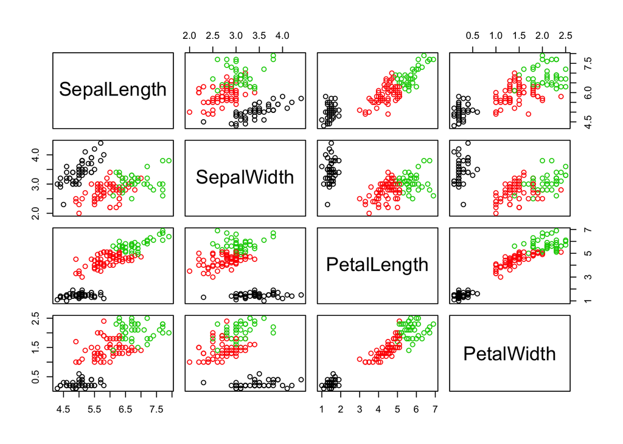

```r
plot(iris[,1:4], col = fit1$cluster)
```

First of all, we want to see the distribution of each group. As the plot shows, while the setosa species is seperated from the others, k-means cannot seperate the other two species.

**(2) Multidimensional scaling**

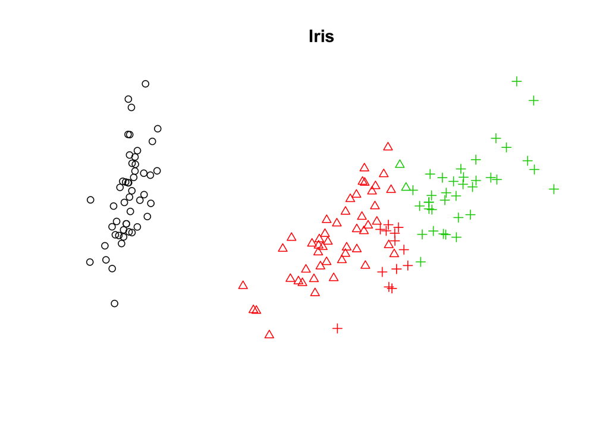

```r
#mds plot
dist = dist(iris[,1:4])
mds = cmdscale(dist)
plot(mds[,1], mds[,2],  type="n", xlab = "", ylab = "", axes = FALSE,main = "Iris")
points(mds[,1], mds[,2], pch = iris$Species_label, col = iris$Kmeans_label)
```

Secondly, we used multidimensional scaling to produce a two-dimensional map. In R, we use cmdscale function. As shown in the map,the circle points represent setosa species, the tranglers represent versicolor species, and the plus symbols are virginica species. Different colors indicate different groups classified by k-means.

We can see that the setosa flowers are all classified correctly by k-means. However, some versicolor flowers are classified as virginica, and vice versa. We can see this more clearly from the confusion matrix below.

**(3) Confusion matrix**

```r
# confusion matrix
table(iris$Name, iris$Kmeans_label)
```

```
##
##                    1  2  3
##   Iris-setosa     50  0  0
##   Iris-versicolor  0 48  2
##   Iris-virginica   0 14 36
```

We used the table function to create the confusion matrix. As the table shows, all setosa flowers are classified correctly, 2 of versicolor flowers are classified as virginica, and 14 virginica flowers are classified as versicolor.